# Prediction Assignment Writeup

Adolfo Zignago

2/8/2018

```r
library(caret)
```

```r
library(ggplot2)
library(ggcorrplot)
library(tree)
```

# Backgound

Using devices such as Jawbone Up, Nike FuelBand, and Fitbit it is now possible to collect a large amount of data about personal activity relatively inexpensively. These type of devices are part of the quantified self movement – a group of enthusiasts who take measurements about themselves regularly to improve their health, to find patterns in their behavior, or because they are tech geeks. One thing that people regularly do is quantify how much of a particular activity they do, but they rarely quantify how well they do it. In this project, your goal will be to use data from accelerometers on the belt, forearm, arm, and dumbell of 6 participants. They were asked to perform barbell lifts correctly and incorrectly in 5 different ways. More information is available from the website here: [See the website](http://groupware.les.inf.puc-rio.br/har) (see the section on the Weight Lifting Exercise Dataset).

# Introduction

The goal of your project is to predict the manner in which they did the exercise. This is the “classe” variable in the training set. You may use any of the other variables to predict with. You should create a report describing how you built your model, how you used cross validation, what you think the expected out of sample error is, and why you made the choices you did. You will also use your prediction model to predict 20 different test cases.

## Data

The training data for this project are available here: (https://d396qusza40orc.cloudfront.net/predmachlearn/pml-training.csv)

The test data are available here: (https://d396qusza40orc.cloudfront.net/predmachlearn/pml-testing.csv)

The data for this project come from this source: (http://web.archive.org/web/20161224072740/http:/groupware.les.inf.puc-rio.br/har).

### Read Raw Data

```r
URLtraining = "https://d396qusza40orc.cloudfront.net/predmachlearn/pml-training.csv"
URLtesting = "https://d396qusza40orc.cloudfront.net/predmachlearn/pml-testing.csv"

CSVtraining = "pml-training.csv"
CSVtesting = "pml-testing.csv"

if(!file.exists(CSVtraining)) {
        download.file(URLtraining, CSVtraining, method = "curl")
}

if(!file.exists(CSVtesting)) {
        download.file(URLtesting, CSVtesting, method = "curl")
}

DATAtraining <- read.csv(CSVtraining, na.strings=c("NA","#DIV/0!",""))
DATAtesting <- read.csv(CSVtesting, na.strings=c("NA","#DIV/0!",""))

dim(DATAtraining)
```

```
## [1] 19622   160
```

```r
dim(DATAtesting)
```

```
## [1]  20 160
```

Reading the file from the URL was the best way to remove all those values.

### Processing and Cleaning Data

```r
# Verify the data
str(DATAtraining)
summary(DATAtraining)

# Varify the data
str(DATAtesting)
summary(DATAtesting)
```

Both datasets have 160 variables, but verifying the data with str and summary, we notice that there ara NA values. We must to take off those columns.

```r
# Remove columns with NA values
DATAtraining <- DATAtraining[,sapply(DATAtraining,function(x) !any(is.na(x)))]

trainingDATA <- DATAtraining[,c(names(DATAtraining[,8:59]),"classe")]


# Remove columns with NA values
DATAtesting <- DATAtesting[,sapply(DATAtesting,function(x) !any(is.na(x)))]

testingDATA <- DATAtesting[,c(names(DATAtesting[,8:59]),"problem_id")]

dim(trainingDATA)
```

```
## [1] 19622    53
```

```r
dim(testingDATA)
```

```
## [1] 20 53
```

After the cleaning process, our data is ready. We taked off 107 variables with ’’, #DIV/0! and NA values. We have removed columns that do not provide important information for this analysis. Such, names, dates, times, etc.

### Partition Data - Cross Validation

For our model and perform a cross validation, we must create a partition. The most recommended is 60% / 40%. That is, 40% of our training data, will be our new testing data.

```r
set.seed(09022018)
trainSet <- createDataPartition(y=trainingDATA$classe, p=0.60, list=FALSE)
training60 <- trainingDATA[trainSet, ]
testing40<- trainingDATA[-trainSet, ]

dim(training60)
```

```
## [1] 11776    53
```

```r
dim(testing40)
```

```
## [1] 7846   53
```

## Prediction Model

### 1 Random Forest

```r
controlrf <- trainControl(method="cv", 5)
rf_model <- train(classe ~ ., data=training60, method="rf", trControl=controlrf, ntree=250)
rf_model
```

```
## Random Forest
##
## 11776 samples
##    52 predictor
##     5 classes: 'A', 'B', 'C', 'D', 'E'
##
## No pre-processing
## Resampling: Cross-Validated (5 fold)
## Summary of sample sizes: 9420, 9421, 9421, 9420, 9422
## Resampling results across tuning parameters:
##
##   mtry  Accuracy   Kappa
##    2    0.9885364  0.9854982
##   27    0.9881960  0.9850673
##   52    0.9796200  0.9742156
##
## Accuracy was used to select the optimal model using the largest value.
## The final value used for the model was mtry = 2.
```

The result of the prediction must be compared with the information of the current testing data.

```r
rf_predict <- predict(rf_model, testing40)
rf_confmatrix <- confusionMatrix(testing40$classe, rf_predict)
rf_confmatrix
```

```
## Confusion Matrix and Statistics
##
##           Reference
## Prediction    A    B    C    D    E
##          A 2224    8    0    0    0
##          B   10 1507    1    0    0
##          C    0    8 1360    0    0
##          D    0    0   29 1257    0
##          E    2    0    2    2 1436
##
## Overall Statistics
##
##                Accuracy : 0.9921
##                  95% CI : (0.9899, 0.9939)
##     No Information Rate : 0.285
##     P-Value [Acc > NIR] : < 2.2e-16
##
##                   Kappa : 0.99
##  Mcnemar's Test P-Value : NA
##
## Statistics by Class:
##
##                      Class: A Class: B Class: C Class: D Class: E
## Sensitivity            0.9946   0.9895   0.9770   0.9984   1.0000
## Specificity            0.9986   0.9983   0.9988   0.9956   0.9991
## Pos Pred Value         0.9964   0.9928   0.9942   0.9774   0.9958
## Neg Pred Value         0.9979   0.9975   0.9951   0.9997   1.0000
## Prevalence             0.2850   0.1941   0.1774   0.1605   0.1830
## Detection Rate         0.2835   0.1921   0.1733   0.1602   0.1830
## Detection Prevalence   0.2845   0.1935   0.1744   0.1639   0.1838
## Balanced Accuracy      0.9966   0.9939   0.9879   0.9970   0.9995
```

```r
rf_acc <- postResample(rf_predict, testing40$classe)
rf_err<-1 - as.numeric(confusionMatrix(testing40$classe, rf_predict)$overall[1])

rf_acc
```

```
##  Accuracy     Kappa
## 0.9920979 0.9900037
```

```r
rf_err
```

```
## [1] 0.007902116
```

### 2 GBM (Generalized Boosted Model)

```r
controlgbm <- trainControl(method = "repeatedcv", number = 5, repeats = 1)
gbm_model  <- train(classe ~ ., data=training60, method = "gbm",
                trControl = controlgbm, verbose = FALSE)
gbm_model
```

```
## Stochastic Gradient Boosting
##
## 11776 samples
##    52 predictor
##     5 classes: 'A', 'B', 'C', 'D', 'E'
##
## No pre-processing
## Resampling: Cross-Validated (5 fold, repeated 1 times)
## Summary of sample sizes: 9420, 9421, 9420, 9422, 9421
## Resampling results across tuning parameters:
##
##   interaction.depth  n.trees  Accuracy   Kappa
##   1                   50      0.7538199  0.6878376
##   1                  100      0.8217563  0.7743586
##   1                  150      0.8568286  0.8188507
##   2                   50      0.8547045  0.8159649
##   2                  100      0.9048919  0.8796588
##   2                  150      0.9317259  0.9136095
##   3                   50      0.8953817  0.8675445
##   3                  100      0.9406419  0.9248850
##   3                  150      0.9577950  0.9466011
##
## Tuning parameter 'shrinkage' was held constant at a value of 0.1
##
## Tuning parameter 'n.minobsinnode' was held constant at a value of 10
## Accuracy was used to select the optimal model using the largest value.
## The final values used for the model were n.trees = 150,
##  interaction.depth = 3, shrinkage = 0.1 and n.minobsinnode = 10.
```

The result of the prediction must be compared with the information of the current testing data.

```r
gbm_predict <- predict(gbm_model, testing40)
gbm_confmatrix <- confusionMatrix(testing40$classe, gbm_predict)
gbm_confmatrix
```

```
## Confusion Matrix and Statistics
##
##           Reference
## Prediction    A    B    C    D    E
##          A 2192   33    4    3    0
##          B   38 1436   42    2    0
##          C    0   40 1306   18    4
##          D    0    4   41 1233    8
##          E    2   10   13   20 1397
##
## Overall Statistics
##
##                Accuracy : 0.9641
##                  95% CI : (0.9597, 0.9681)
##     No Information Rate : 0.2845
##     P-Value [Acc > NIR] : < 2e-16
##
##                   Kappa : 0.9545
##  Mcnemar's Test P-Value : 2.6e-05
##
## Statistics by Class:
##
##                      Class: A Class: B Class: C Class: D Class: E
## Sensitivity            0.9821   0.9429   0.9289   0.9663   0.9915
## Specificity            0.9929   0.9870   0.9904   0.9919   0.9930
## Pos Pred Value         0.9821   0.9460   0.9547   0.9588   0.9688
## Neg Pred Value         0.9929   0.9863   0.9846   0.9934   0.9981
## Prevalence             0.2845   0.1941   0.1792   0.1626   0.1796
## Detection Rate         0.2794   0.1830   0.1665   0.1572   0.1781
## Detection Prevalence   0.2845   0.1935   0.1744   0.1639   0.1838
## Balanced Accuracy      0.9875   0.9650   0.9596   0.9791   0.9922
```

```r
gbm_acc <- postResample(gbm_predict, testing40$classe)
gbm_err<-1 - as.numeric(confusionMatrix(testing40$classe, gbm_predict)$overall[1])

gbm_acc
```

```
##  Accuracy     Kappa
## 0.9640581 0.9545392
```

```r
gbm_err
```

```
## [1] 0.03594188
```

Random Forest has accuracy of: **0.9920979** and GBM has **0.9640581**. We decided to apply Random Forest to predict the 20 observations results (testingDATA) as shown below.

## Predict Results (Test Data)

```r
final <- predict(rf_model, testingDATA)
final
```

```
##  [1] B A B A A E D B A A B C B A E E A B B B
## Levels: A B C D E
```

# Apendix

## Correlation

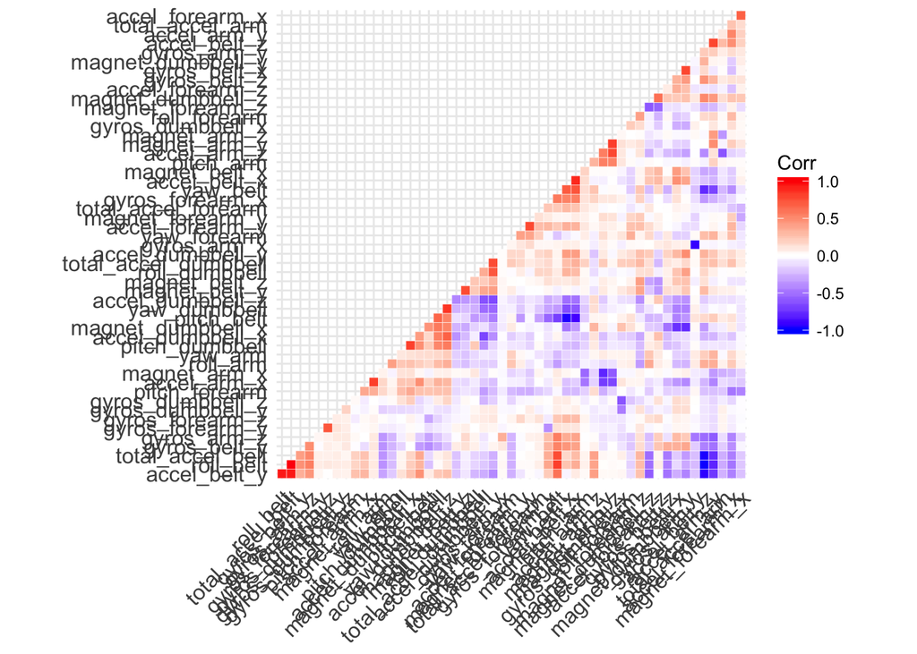

```r
corr_model <- cor(testing40[, -53])
ggcorrplot(corr_model, hc.order = TRUE, type = "lower",
     outline.col = "white")
```

```r
tr_rfmodel <- tree(classe ~., data = testing40)
tr_rfmodel
```

```
## node), split, n, deviance, yval, (yprob)
##       * denotes terminal node
##
##   1) root 7846 24910.0 A ( 0.284476 0.193474 0.174356 0.163905 0.183788 )
##     2) roll_belt < 129.5 7128 22170.0 A ( 0.309484 0.212963 0.191919 0.180415 0.105219 )
##       4) pitch_forearm < -34.6 632     0.0 A ( 1.000000 0.000000 0.000000 0.000000 0.000000 ) *
##       5) pitch_forearm > -34.6 6496 20540.0 A ( 0.242303 0.233682 0.210591 0.197968 0.115456 )
##        10) magnet_dumbbell_y < 437.5 5493 17160.0 A ( 0.280539 0.183506 0.242490 0.189150 0.104315 )
##          20) roll_forearm < 123.5 3444 10080.0 A ( 0.394599 0.186411 0.188153 0.172184 0.058653 )
##            40) roll_forearm < -64.95 1047  3285.0 D ( 0.149952 0.218720 0.140401 0.302770 0.188157 )
##              80) magnet_dumbbell_x < -461.5 520  1444.0 D ( 0.009615 0.171154 0.275000 0.348077 0.196154 ) *
##              81) magnet_dumbbell_x > -461.5 527  1482.0 A ( 0.288425 0.265655 0.007590 0.258065 0.180266 ) *
##            41) roll_forearm > -64.95 2397  5935.0 A ( 0.501460 0.172299 0.209011 0.115144 0.002086 )
##              82) magnet_dumbbell_z < -27.5 912  1205.0 A ( 0.773026 0.188596 0.009868 0.028509 0.000000 ) *
##              83) magnet_dumbbell_z > -27.5 1485  3999.0 A ( 0.334680 0.162290 0.331313 0.168350 0.003367 )
##               166) roll_arm < -3.06 930  2307.0 C ( 0.202151 0.065591 0.459140 0.267742 0.005376 )
##                 332) yaw_belt < 162.5 459   698.2 C ( 0.130719 0.013072 0.771242 0.076253 0.008715 ) *
##                 333) yaw_belt > 162.5 471  1192.0 D ( 0.271762 0.116773 0.154989 0.454352 0.002123 ) *
##               167) roll_arm > -3.06 555  1059.0 A ( 0.556757 0.324324 0.117117 0.001802 0.000000 ) *
##          21) roll_forearm > 123.5 2049  6271.0 C ( 0.088824 0.178624 0.333821 0.217667 0.181064 )
##            42) magnet_forearm_z < -245 160   240.0 A ( 0.762500 0.150000 0.000000 0.018750 0.068750 ) *
##            43) magnet_forearm_z > -245 1889  5451.0 C ( 0.031763 0.181048 0.362096 0.234516 0.190577 )
##              86) accel_forearm_x < -106.5 577  1460.0 D ( 0.060659 0.084922 0.240901 0.530329 0.083189 ) *
##              87) accel_forearm_x > -106.5 1312  3549.0 C ( 0.019055 0.223323 0.415396 0.104421 0.237805 )
##               174) pitch_belt < 0.425 104   141.7 D ( 0.000000 0.000000 0.000000 0.576923 0.423077 ) *
##               175) pitch_belt > 0.425 1208  3123.0 C ( 0.020695 0.242550 0.451159 0.063742 0.221854 )
##                 350) magnet_dumbbell_z < 284.5 992  2333.0 C ( 0.007056 0.220766 0.541331 0.064516 0.166331 ) *
##                 351) magnet_dumbbell_z > 284.5 216   526.4 E ( 0.083333 0.342593 0.037037 0.060185 0.476852 ) *
##        11) magnet_dumbbell_y > 437.5 1003  2461.0 B ( 0.032901 0.508475 0.035892 0.246261 0.176471 )
##          22) total_accel_dumbbell < 6.5 318   459.6 D ( 0.000000 0.198113 0.003145 0.742138 0.056604 )
##            44) yaw_belt < -2.81 57     0.0 B ( 0.000000 1.000000 0.000000 0.000000 0.000000 ) *
##            45) yaw_belt > -2.81 261   200.2 D ( 0.000000 0.022989 0.003831 0.904215 0.068966 ) *
##          23) total_accel_dumbbell > 6.5 685  1345.0 B ( 0.048175 0.652555 0.051095 0.016058 0.232117 )
##            46) roll_belt < -0.56 117     0.0 E ( 0.000000 0.000000 0.000000 0.000000 1.000000 ) *
##            47) roll_belt > -0.56 568   902.6 B ( 0.058099 0.786972 0.061620 0.019366 0.073944 ) *
##     3) roll_belt > 129.5 718   223.6 E ( 0.036212 0.000000 0.000000 0.000000 0.963788 ) *
```

[figure not shown]

```r
plot(tr_rfmodel)
```

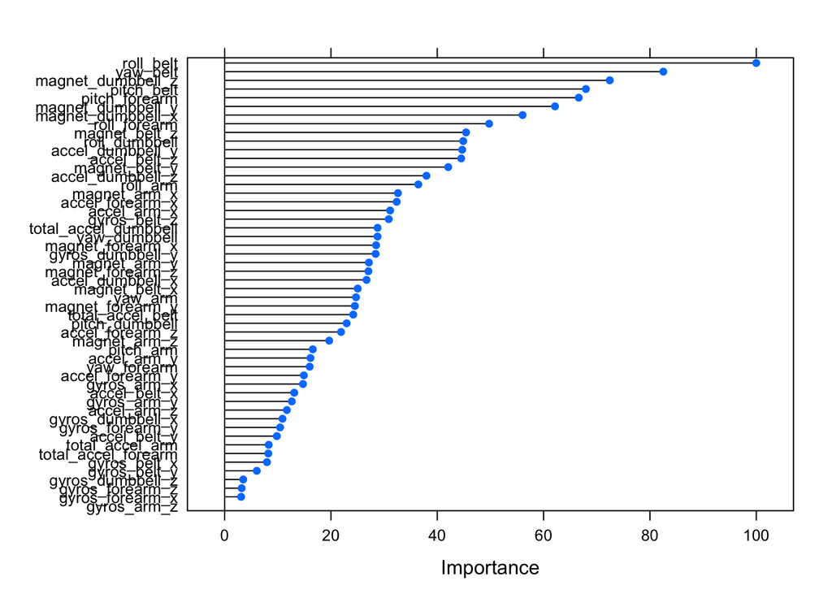

```r
# Importance
plot(varImp(rf_model, scale = TRUE))
```

## Plot GBM

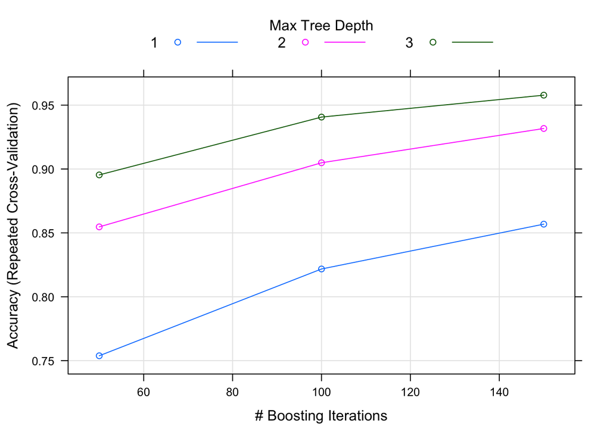

```r
plot(gbm_model)
```